# Basic Concepts

Data Team, [Center on Budget and Policy Priorities](https://www.cbpp.org)

Spring 2021

# Working directories

Almost every Stata script begins with setting the working directory. The working directory is the place where Stata will look for any files you reference later in the script. You set your working directory with the command `cd`.

```stata
cd "C:/Users/my_username/Documents/project_folder/"
```

Stata’s `cd` command understands ~ as an abbreviation for the home directory, so you can use this shortcut instead.

```stata
cd "~/Documents/project_folder/"
```

To see your working directory, type:

```stata
pwd
```

There are two advantages of using working directories:

1. Once you set it, you won’t need to write out the full file path of any file inside the working directory.
   - Without setting the working directory:

     > ```stata
     > use "C:/Users/my_username/Documents/project_folder/data-raw/my_data.dta"
     > * a bunch of code here *
     > save "C:/Users/my_username/Documents/project_folder/data/my_final_data.dta"
     > ```

   - With setting the working directory:

     > ```stata
     > cd "C:/Users/my_username/Documents/project_folder/"
     > use "data-raw/my_data.dta"
     > * a bunch of code here *
     > save "data/my_final_data.dta"
     > ```

2. If you move your project files from one folder to another, or rename the folder, you only need to change one line of code.
   - For instance, if you renamed project_folder to new_project_folder, you’d simply change the `cd` command and the rest of your code would still work fine. :

     > ```stata
     > cd "C:/Users/my_username/Documents/new_project_folder/
     > ```

# Log files

After you have set the working directory, the next step is usually to open a log file. Log file is sort of built-in tape recorder where you can:

1. Retrieve the output of your work (except graphs)
2. Keep a record of your work

This will create the file `myfile.smcl` in your working directory:

```stata
log using myfile, replace
```

By default, log files are recorded in a format called *Stata Markup and Control Language (SMCL)* and can be printed or converted to plain text. You can also specify `text` option if you want the log file to be in text format and read it in your word processor.

Once you begin a log file, you can suspend it any time using the `log off` command and resume later with `log on`.

When you are done working on a project, type `log close` to stop logging and close the file.

# Examining the dataset

The `describe` command is an easy way to get acquainted with your dataset. It lists all the variables in the dataset, along with their types and variable labels.

```stata
sysuse auto, clear
describe
```

```
(1978 Automobile Data)


Contains data from /Applications/Stata/ado/base/a/auto.dta
  obs:            74                          1978 Automobile Data
 vars:            12                          13 Apr 2016 17:45
 size:         3,182                          (_dta has notes)
----------------------------------------------------------------------------------------------------
              storage   display    value
variable name   type    format     label      variable label
----------------------------------------------------------------------------------------------------
make            str18   %-18s                 Make and Model
price           int     %8.0gc                Price
mpg             int     %8.0g                 Mileage (mpg)
rep78           int     %8.0g                 Repair Record 1978
headroom        float   %6.1f                 Headroom (in.)
trunk           int     %8.0g                 Trunk space (cu. ft.)
weight          int     %8.0gc                Weight (lbs.)
length          int     %8.0g                 Length (in.)
turn            int     %8.0g                 Turn Circle (ft.)
displacement    int     %8.0g                 Displacement (cu. in.)
gear_ratio      float   %6.2f                 Gear Ratio
foreign         byte    %8.0g      origin     Car type
----------------------------------------------------------------------------------------------------
Sorted by: foreign
```

We can get a quick glimpse at the data by browsing it in the Data Editor or with the `browse` command:

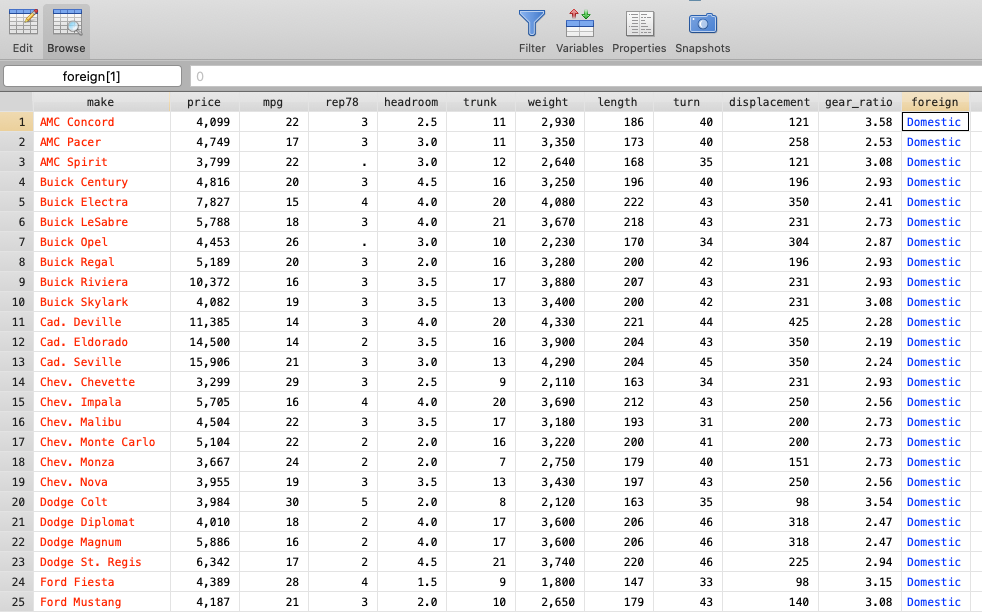

From browsing, we see that the values for the **foreign** variable are blue. That means the values of the variable are labeled. Value labels are a helpful way to convey the meaning of logical or categorical variables. In the first row, **foreign** appears as Domestic, but if we click the cell to view the underlying value, it’s **0**.

There are several ways to reveal value labels:

```stata
tabulate foreign
```

```
   Car type |      Freq.     Percent        Cum.
------------+-----------------------------------
   Domestic |         52       70.27       70.27
    Foreign |         22       29.73      100.00
------------+-----------------------------------
      Total |         74      100.00
```

```stata
tabulate foreign, nolabel
```

```
   Car type |      Freq.     Percent        Cum.
------------+-----------------------------------
          0 |         52       70.27       70.27
          1 |         22       29.73      100.00
------------+-----------------------------------
      Total |         74      100.00
```

```stata
label list
```

```
origin:
           0 Domestic
           1 Foreign
```

```stata
codebook foreign
```

```
foreign                                                                                     Car type
----------------------------------------------------------------------------------------------------

                  type:  numeric (byte)
                 label:  origin

                 range:  [0,1]                        units:  1
         unique values:  2                        missing .:  0/74

            tabulation:  Freq.   Numeric  Label
                            52         0  Domestic
                            22         1  Foreign
```

For information on how to create variable and value labels, see `help label`.

The `codebook` command is especially helpful if we want to know how many missing values a variable has. Another way to find out this is by using the `misstable` command:

```stata
misstable summarize
```

```
                                                               Obs<.
                                                +------------------------------
               |                                | Unique
      Variable |     Obs=.     Obs>.     Obs<.  | values        Min         Max
  -------------+--------------------------------+------------------------------
         rep78 |         5                  69  |      5          1           5
  -----------------------------------------------------------------------------
```

The output table indicates that the **rep78** variable, which shows repair records, has *5* missing values. We can find out more about this variable using the `inspect` command.

```stata
inspect rep78
```

```
rep78:  Repair Record 1978                      Number of Observations
--------------------------             ---------------------------------------
                                             Total      Integers   Nonintegers
|          #                 Negative            -             -             -
|          #                 Zero                -             -             -
|          #                 Positive           69            69             -
|          #   #                       -----------   -----------   -----------
|          #   #   #         Total              69            69             -
|  .   #   #   #   #         Missing             5
+----------------------                -----------
1                     5                         74
   (5 unique values)
```

# Descriptive statistics

The `summarize` command gives a brief summary statistics about all the variables. In the output table, we can see the number of observations, mean, standard deviation, minimum, and maximum for each variable.

```stata
summarize
```

```
    Variable |        Obs        Mean    Std. Dev.       Min        Max
-------------+---------------------------------------------------------
        make |          0
       price |         74    6165.257    2949.496       3291      15906
         mpg |         74     21.2973    5.785503         12         41
       rep78 |         69    3.405797    .9899323          1          5
    headroom |         74    2.993243    .8459948        1.5          5
-------------+---------------------------------------------------------
       trunk |         74    13.75676    4.277404          5         23
      weight |         74    3019.459    777.1936       1760       4840
      length |         74    187.9324    22.26634        142        233
        turn |         74    39.64865    4.399354         31         51
displacement |         74    197.2973    91.83722         79        425
-------------+---------------------------------------------------------
  gear_ratio |         74    3.014865    .4562871       2.19       3.89
     foreign |         74    .2972973    .4601885          0          1
```

To find out the median, we can use the `detail` option on the `summarize` command.

```stata
summarize trunk, detail
```

```
                    Trunk space (cu. ft.)
-------------------------------------------------------------
      Percentiles      Smallest
 1%            5              5
 5%            7              6
10%            8              7       Obs                  74
25%           10              7       Sum of Wgt.          74

50%           14                      Mean           13.75676
                        Largest       Std. Dev.      4.277404
75%           17             21
90%           20             21       Variance       18.29619
95%           21             22       Skewness       .0292034
99%           23             23       Kurtosis       2.192052
```

In this example, we can see that the median of the trunk space is *14 cu. ft.*

In *frequency tables*, we can see the mode of a variable by finding the largest `Freq.` or `Percent`. The mode is the trunk space is *16 cu. ft.*

```stata
tab trunk
```

```
Trunk space |
  (cu. ft.) |      Freq.     Percent        Cum.
------------+-----------------------------------
          5 |          1        1.35        1.35
          6 |          1        1.35        2.70
          7 |          3        4.05        6.76
          8 |          5        6.76       13.51
          9 |          4        5.41       18.92
         10 |          5        6.76       25.68
         11 |          8       10.81       36.49
         12 |          3        4.05       40.54
         13 |          4        5.41       45.95
         14 |          4        5.41       51.35
         15 |          5        6.76       58.11
         16 |         12       16.22       74.32
         17 |          8       10.81       85.14
         18 |          1        1.35       86.49
         20 |          6        8.11       94.59
         21 |          2        2.70       97.30
         22 |          1        1.35       98.65
         23 |          1        1.35      100.00
------------+-----------------------------------
      Total |         74      100.00
```

> Stata commands can be abbreviated. For instance, instead of typing `tabulate`, we used `tab`.

Frequency tables are especially useful when analyzing categorical data.

```stata
tab foreign
```

```
   Car type |      Freq.     Percent        Cum.
------------+-----------------------------------
   Domestic |         52       70.27       70.27
    Foreign |         22       29.73      100.00
------------+-----------------------------------
      Total |         74      100.00
```

- `Freq.` provides a raw count of each value. In this case, the dataset consists of 52 domestic and 22 foreign car models.
- `Percent` gives the relative frequency for each value. For example, 29.73% of the car models in this dataset are foreign.
- `Cum.` is the cumulative frequency in ascending order of the values. For example, 70.27% of the car models in this dataset are domestic.

If we want to quickly find out the differences in gas mileage across the cars’ origins, we can use the `summarize` option of the `tab` command:

```stata
tabulate foreign, summarize(mpg)
```

```
            |      Summary of Mileage (mpg)
   Car type |        Mean   Std. Dev.       Freq.
------------+------------------------------------
   Domestic |   19.826923   4.7432972          52
    Foreign |   24.772727   6.6111869          22
------------+------------------------------------
      Total |   21.297297   5.7855032          74
```

This is a one-way table, so tabulate uses one variable. The variable being summarized is passed to the `tabulate` command with an option. Though we will not do it here, the `summarize` option can also be used with two-way tables.